# Estadística Descriptiva Multivariada

Análisis de Correspondencias Simples y Múltiples

Jimmy A Corzo S, PhD

jacorzos@unal.edu.co

Giovany Babativa-Márquez, PhD

jgbabativam@unal.edu.co

# Análisis de Correspondencias

## Contenido: ACS y ACM

**Análisis de Correspondencias Simples**

1. Descripción del método
2. Tablas de contingencia y perfiles
3. Inercia y distancia $\chi^2$
4. Obtención de los factores
5. Guías para la interpretación
6. Ej. 1: Sentimientos ante normas (ECC)
7. Ej. 2: Confianza en la justicia en 38 países
8. Ej. 3: Candidatos Bogotá 2023

**Análisis de Correspondencias Múltiples**

9. Del ACS al ACM
10. Tabla disyuntiva y Tabla de Burt
11. Inercia de modalidades
12. Guías para la interpretación
13. Ej. 1: Justificaciones desobediencia (ECC)
14. Ej. 2: Confianza en instituciones — LAPOP Colombia 2021
15. Laboratorio

# Análisis de correspondencias simples

## ¿Qué es el ACS?

El ACP requiere variables **cuantitativas**. Cuando los datos provienen de encuestas con respuestas categóricas, las escalas son **códigos** asignados a modalidades: no hay operaciones aritméticas con sentido entre ellas.

El **Análisis de Correspondencias Simples (ACS)**:

- Es una extensión del ACP para identificar relaciones entre **dos variables cualitativas**.
- Visualiza tablas de frecuencias o **tablas de contingencia** en un plano de pocas dimensiones.
- Puede interpretarse como un ACP para variables cualitativas.
- Identifica asociaciones entre las **modalidades de respuesta** de ambas variables.

**Note**

Cuando se trata de **más de dos** variables cualitativas, el método se generaliza al **Análisis de Correspondencias Múltiples (ACM)**, tratado en la segunda parte de esta presentación.

## Escalas de variables cualitativas

- **Nominal:** códigos que clasifican objetos sin orden. *Ejemplos:* sexo, ciudad, estado civil, universidad, país.
- **Ordinal o categórica:** categorías que indican **jerarquía u orden**. *Ejemplos:* estrato socioeconómico, nivel educativo, posición en ranking.
- **Likert:** escala ordinal para grados de aprobación o acuerdo. *Modalidades típicas:* Totalmente en desacuerdo · En desacuerdo · Indiferente · De acuerdo · Totalmente de acuerdo.
- **Hedonista:** escala ordinal de **niveles de preferencia o agrado**. *Modalidades:* Me desagrada mucho · Me desagrada · Ni me agrada ni desagrada · Me agrada · Me agrada mucho.

> Las opciones de respuesta se denominan **modalidades**. Las variables generadas por estas codificaciones son **variables cualitativas**.

# Tablas de contingencia

## Estructura de la tabla de contingencia

Sea $X$ la variable fila con $I$ modalidades y $Y$ la variable columna con $J$ modalidades. La tabla de contingencia es:

$$G = \{n_{ij}\}, \quad i = 1,\ldots,I, \quad j = 1,\ldots,J$$

donde $n_{ij}$ es el número de respuestas simultáneas a la modalidad $i$ de $X$ y la modalidad $j$ de $Y$.

## Estructura de la tabla de contingencia

$$\begin{array}{c|cccccc|c}
& 1 & 2 & \cdots & j & \cdots & J & \\
\hline
1 & n_{11} & n_{12} & \cdots & n_{1j} & \cdots & n_{1J} & n_{1.} \\
& \vdots & \vdots & & \vdots & & \vdots & \vdots \\
i & n_{i1} & n_{i2} & \cdots & n_{ij} & \cdots & n_{iJ} & n_{i.} \\
& \vdots & \vdots & & \vdots & & \vdots & \vdots \\
I & n_{I1} & n_{I2} & \cdots & n_{Ij} & \cdots & n_{IJ} & n_{I.} \\
\hline
& n_{.1} & n_{.2} & \cdots & n_{.j} & \cdots & n_{.J} & n
\end{array}$$

Las **frecuencias marginales** son: $\;n_{i.} = \sum_{j=1}^J n_{ij}$ (fila) $\;$ y $\;$ $n_{.j} = \sum_{i=1}^I n_{ij}$ (columna).

## De frecuencias a perfiles

Las frecuencias absolutas $n_{ij}$ dependen del total $n$ y no permiten comparar directamente. Las frecuencias relativas $f_{ij} = n_{ij}/n$ tampoco eliminan el efecto de las marginales.

La solución son los **perfiles** (frecuencias condicionales):

$$\text{Perfiles fila:} \quad \frac{f_{ij}}{f_{i.}} = \frac{n_{ij}}{n_{i.}} \qquad \text{Perfiles columna:} \quad \frac{f_{ij}}{f_{.j}} = \frac{n_{ij}}{n_{.j}}$$

donde $f_{i.} = n_{i.}/n$ y $f_{.j} = n_{.j}/n$ son las frecuencias marginales relativas.

> $G_I = (f_{.1}, \ldots, f_{.J})$ es el **centroide de filas** (perfil promedio de filas). $G_J = (f_{1.}, \ldots, f_{I.})$ es el **centroide de columnas**.

## Inercia y distancia $\chi^2$

Si $X$ e $Y$ son **independientes**, se espera $f_{ij} = f_{i.} f_{.j}$. Se definen las **frecuencias esperadas**:

$$\hat{e}_{ij} = f_{i.} f_{.j}$$

Las **distancias estandarizadas** entre observado y esperado son:

$$z_{ij} = \frac{f_{ij} - \hat{e}_{ij}}{\sqrt{\hat{e}_{ij}}}$$

## Inercia y distancia $\chi^2$

La estadística $\chi^2$ y la **inercia total** son:

$$\chi^2 = n \sum_{i=1}^I \sum_{j=1}^J z_{ij}^2 \qquad \Longrightarrow \qquad T = \frac{\chi^2}{n} = \sum_{i=1}^I \sum_{j=1}^J z_{ij}^2$$

**Important**

La **inercia** $T$ elimina el efecto del tamaño muestral. Es la varianza total que el ACS descompone en factores.

# Obtención de los factores

## Diferencias entre ACP y ACS

- **ACP**: En las tablas de datos del ACP las filas representan objetos y las columnas son las variables, de manera que el análisis por filas es un análisis de similitudes entre objetos, el análisis por columnas es un análisis de correlación entre variables.
- **ACS**: Las filas y columnas representan las modalidades de dos variables cualitativas, y por tanto la interpretación de los dos análisis es la misma. Asociación entre modalidades de la variable que está en las filas (columnas) y el análisis simultáneo de filas y columnas es para identificar el grado de asociación entre modalidades de las dos variables.

## Factores del ACS

Las **coordenadas** de filas y columnas sobre el $\alpha$-ésimo factor son promedios ponderados de las distancias estandarizadas:

$$r_{i\alpha} = \sum_{j=1}^J z_{ij}\, u_{j\alpha} = \sum_{j=1}^J \frac{f_{ij} - \hat{e}_{ij}}{\sqrt{\hat{e}_{ij}}}\, u_{j\alpha} \qquad \text{(filas)}$$

$$c_{j\alpha} = \sum_{i=1}^I z_{ij}\, v_{i\alpha} = \sum_{i=1}^I \frac{f_{ij} - \hat{e}_{ij}}{\sqrt{\hat{e}_{ij}}}\, v_{i\alpha} \qquad \text{(columnas)}$$

**Equivalencia con perfiles:** un enfoque que produce los mismos resultados consiste en proyectar directamente los perfiles fila y columna. Las coordenadas de las filas son:

$$r_{\alpha i} = \frac{1}{f_{i.}} \sum_{j=1}^J \frac{f_{ij}}{f_{.j}}\, u_{j\alpha}$$

## Ecuaciones de transición

Los vectores propios de las matrices de filas y columnas están relacionados por:

$$v_\alpha = \frac{1}{\sqrt{\lambda_\alpha}}\, F\, D_J^{-1}\, u_\alpha \qquad \qquad u_\alpha = \frac{1}{\sqrt{\lambda_\alpha}}\, F^\prime\, D_I^{-1}\, v_\alpha$$

donde $F = \{f_{ij}\}$ es la matriz de frecuencias relativas, $D_I = \text{diag}(f_{i.})$ y $D_J = \text{diag}(f_{.j})$.

> Las ecuaciones de transición permiten, a partir de las coordenadas de un espacio, calcular las del otro. Es la base de la **representación simultánea** de filas y columnas en el mismo plano.

**Filas y columnas suplementarias:** para filas o columnas que no participan en el cálculo, sus coordenadas se obtienen proyectando sus perfiles sobre los factores ya calculados.

# Interpretación del ACS

## Tres herramientas de interpretación

1. **Coordenadas** ($r_{i\alpha}$, $c_{j\alpha}$): posición de la modalidad sobre el factor.
2. **Contribuciones:** aporte de la modalidad a la varianza del factor:
   $$C_\alpha(i) = \frac{f_{i.}\, r_{\alpha i}^2}{\lambda_\alpha} \qquad C_\alpha(j) = \frac{f_{.j}\, c_{\alpha j}^2}{\lambda_\alpha}$$
3. **Cosenos cuadrados:** capacidad del factor para representar la modalidad:
   $$\cos^2_\alpha(i) = \frac{r_{\alpha i}^2}{d^2(i, G_I)} \qquad \cos^2_\alpha(j) = \frac{c_{\alpha j}^2}{d^2(j, G_J)}$$

**Note**

Modalidades con **coordenada alta + contribución alta + cos² alto** tipifican el factor y pueden usarse como indicadores de las propiedades que define ese factor.

## Reglas de interpretación de las coordenadas

- **Puntos fila, columna o mixtos cercanos entre sí** → los encuestados que contestaron una modalidad también contestaron la otra; sus distribuciones son similares.
- **Puntos cercanos al centro del plano** → modalidades con frecuencias **altas** de respuesta; representan la opinión de la mayoría (punto promedio o modal).
- **Puntos lejanos del origen** → modalidades con frecuencias **bajas** de respuesta; son las que más distinguen a los individuos.
- **Puntos en extremos opuestos del plano** → baja frecuencia de respuesta **y** distribuciones opuestas; indican opiniones contrapuestas.

**Warning**

El ACS **aleja del origen** las modalidades poco frecuentes, identificando así las características que más distinguen a los objetos.

# Ejemplo 1: Sentimientos ante normas — ECC

## Encuesta de Cultura Ciudadana

La **Encuesta de Cultura Ciudadana (ECC)** fue realizada por Corporación Visionarios en varias ciudades latinoamericanas. Incluye preguntas sobre sentimientos hacia normas, facilidad para cumplir la ley, celebración de acuerdos, confianza, seguridad y pluralismo.

Dos preguntas permiten explorar si quienes tienen sentimientos positivos hacia las normas también les queda más fácil cumplirlas:

**P16.** *De modo general, las palabras* regla o norma *despiertan en Usted un sentimiento:*

1. Muy negativo | 2. Negativo | 3. Indiferente | 4. Positivo | 5. Muy positivo |

**P17b.** *Le queda fácil actuar conforme a la ley:*

1. Nunca | 2. Casi nunca | 3. Casi siempre | 4. Siempre |

## Carga de los datos

```r
library(pacman)
p_load(tidyverse, FactoMineR, factoextra, gt, janitor, corrplot)

url <- "https://github.com/jgbabativam/Curso_Multivariado/raw/main/Datos/"
CCLatin <- read.csv2(paste0(url, "Muestra_CC.csv"), sep = ";")
```

```r
t16x17 <- table(CCLatin$p16, CCLatin$p17_b)
```

Tabla de contingencia: sentimientos ante normas × facilidad para cumplir la ley

| P16 \ P17b | p17b_FACL=1_n | p17b_FACL=2_cn | p17b_FACL=3_cs | p17b_FACL=4_s |
| --- | --- | --- | --- | --- |
| p16_PNOR=1_muyneg | 1 | 0 | 0 | 7 |
| p16_PNOR=2_neg | 3 | 12 | 19 | 21 |
| p16_PNOR=3_indif | 0 | 3 | 8 | 4 |
| p16_PNOR=4_posi | 27 | 113 | 523 | 547 |
| p16_PNOR=5_muypos | 5 | 17 | 84 | 140 |

## Perfiles fila

```r
perfilesF <- as.data.frame.matrix(t16x17)
perf_fil  <- cbind(perfilesF, TotFil = rowSums(t16x17))
perfilas  <- round(perf_fil / perf_fil$TotFil, 3)
```

Perfiles fila: distribución de facilidad para cumplir la ley según sentimiento ante normas

| Sentimiento (P16) | p17b_FACL=1_n | p17b_FACL=2_cn | p17b_FACL=3_cs | p17b_FACL=4_s | TotFil |
| --- | --- | --- | --- | --- | --- |
| p16_PNOR=1_muyneg | 0.125 | 0.000 | 0.000 | 0.875 | 1 |
| p16_PNOR=2_neg | 0.055 | 0.218 | 0.345 | 0.382 | 1 |
| p16_PNOR=3_indif | 0.000 | 0.200 | 0.533 | 0.267 | 1 |
| p16_PNOR=4_posi | 0.022 | 0.093 | 0.432 | 0.452 | 1 |
| p16_PNOR=5_muypos | 0.020 | 0.069 | 0.341 | 0.569 | 1 |

**Note**

## Perfiles columna

```r
perColum  <- round(sweep(perfilesF, 2, colSums(perfilesF), "/"), 3)
```

Perfiles columna para el sentimiento ante reglas o normas vs. facilidad para obedecer la ley

| Sentimiento (P16) | p17b_FACL=1_n | p17b_FACL=2_cn | p17b_FACL=3_cs | p17b_FACL=4_s |
| --- | --- | --- | --- | --- |
| p16_PNOR=1_muyneg | 0.028 | 0.000 | 0.000 | 0.010 |
| p16_PNOR=2_neg | 0.083 | 0.083 | 0.030 | 0.029 |
| p16_PNOR=3_indif | 0.000 | 0.021 | 0.013 | 0.006 |
| p16_PNOR=4_posi | 0.750 | 0.779 | 0.825 | 0.761 |
| p16_PNOR=5_muypos | 0.139 | 0.117 | 0.132 | 0.195 |

**Note**

Se elimina el efecto del total de encuestados. Hay una fuerte similitud entre las distribuciones según la facilidad para actuar conforme a la ley. Lo paradógico es que cualquiera sea el grado de facilidad para actuar conforme a la ley, en todos los casos domina el sentimiento positivo y en menor grado muy positivo.

## ACS — Tabla de contingencia ECC

```r
acs_p16x17 <- CA(as.data.frame.matrix(t16x17), graph = FALSE)
```

```r
eig_acs <- get_eigenvalue(acs_p16x17)
round(eig_acs, 3)
```

```
      eigenvalue variance.percent cumulative.variance.percent
Dim.1      0.016           62.569                      62.569
Dim.2      0.008           32.668                      95.237
Dim.3      0.001            4.763                     100.000
```

## Análisis de las filas — Factores 1 y 2

| Modalidad | Coordenadas F1 | Coordenadas F2 | Contribuciones (%) F1 | Contribuciones (%) F2 | Cos² F1 | Cos² F2 |
| --- | --- | --- | --- | --- | --- | --- |
| p16_PNOR=1_muyneg | -0.94 | 0.60 | 28.84 | 22.46 | 0.68 | 0.28 |
| p16_PNOR=2_neg | 0.25 | 0.41 | 13.91 | 72.25 | 0.27 | 0.73 |
| p16_PNOR=3_indif | 0.50 | -0.01 | 15.21 | 0.01 | 0.94 | 0.00 |
| p16_PNOR=4_posi | 0.03 | -0.02 | 3.96 | 5.24 | 0.52 | 0.36 |
| p16_PNOR=5_muypos | -0.19 | 0.01 | 38.09 | 0.05 | 0.92 | 0.00 |

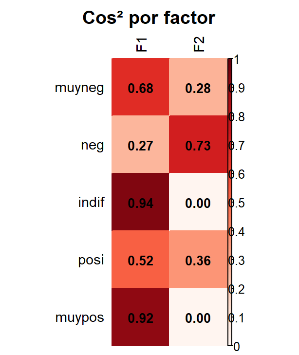

**Note**

## Plano factorial — Análisis por filas

```r
fviz_ca_row(acs_p16x17, repel = TRUE, col.row = "cos2",
            gradient.cols = c("#00AFBB", "#E7B800", "#FC4E07"),
            title = "Análisis por filas — Sentimientos ante palabras como regla o norma") + theme_bw()
```

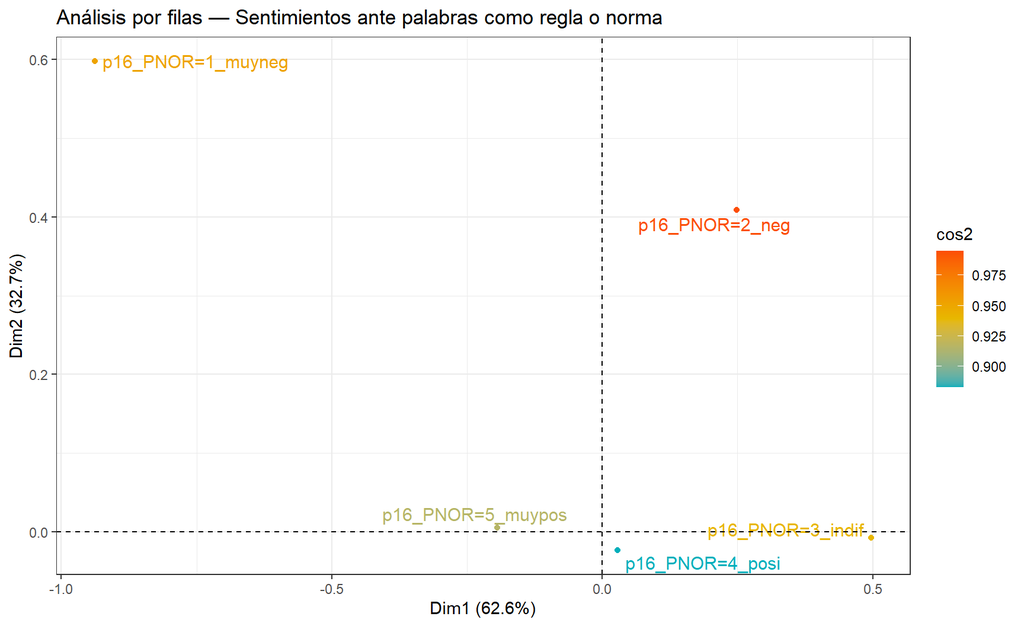

## Indicadores de columnas — Facilidad para actuar conforme a la ley

| Modalidad | Coordenadas F1 | Coordenadas F2 | Contribuciones (%) F1 | Contribuciones (%) F2 | Cos² F1 | Cos² F2 |
| --- | --- | --- | --- | --- | --- | --- |
| p17b_FACL=1_n | -0.09 | 0.37 | 1.15 | 38.85 | 0.04 | 0.79 |
| p17b_FACL=2_cn | 0.24 | 0.18 | 33.81 | 35.04 | 0.63 | 0.34 |
| p17b_FACL=3_cs | 0.09 | -0.07 | 20.79 | 25.62 | 0.59 | 0.38 |
| p17b_FACL=4_s | -0.12 | 0.01 | 44.25 | 0.49 | 0.98 | 0.01 |

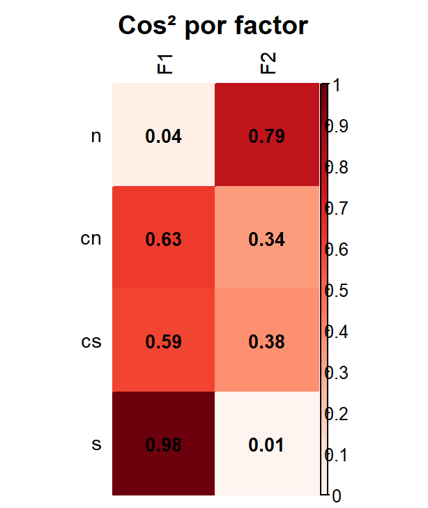

**Note**

**Factor 1** está mejor tipificado por **siempre** (p17b_FACL=4_s): mayor contribución (44.25%) y mejor representada sobre este factor (cos²=0.98), con coordenada negativa (−0.12). La modalidad **casi nunca** tiene la mayor coordenada positiva (0.24) y alta contribución (33.81%). **Factor 2** es un indicador de poca facilidad para cumplir la ley: **nunca** (p17b_FACL=1_n) tiene la mayor coordenada (0.37), la mayor contribución (38.85%) y el mejor cos² en F2 (0.79), situándose lejos del origen.

## Análisis por columnas

```r
fviz_ca_col(acs_p16x17, repel = TRUE, col.col = "cos2",
            gradient.cols = c("#00AFBB", "#E7B800", "#FC4E07"),
            title = "Análisis por columnas — Facilidad para actuar conforme a la ley") + theme_bw()
```

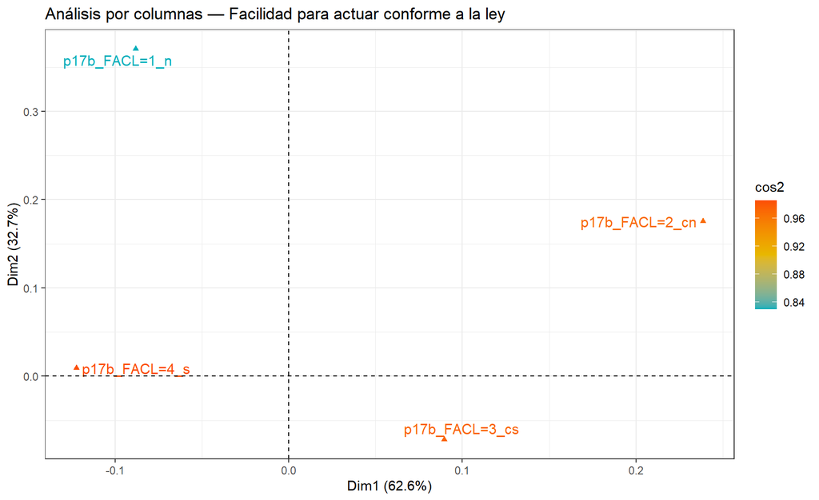

## Representación simultánea

```r
fviz_ca_biplot(acs_p16x17, repel = TRUE, col.row = "#0077b6", col.col = "#C0392B",
               title = "Asociación entre sentimientos y facilidad para cumplir la ley") + theme_bw()
```

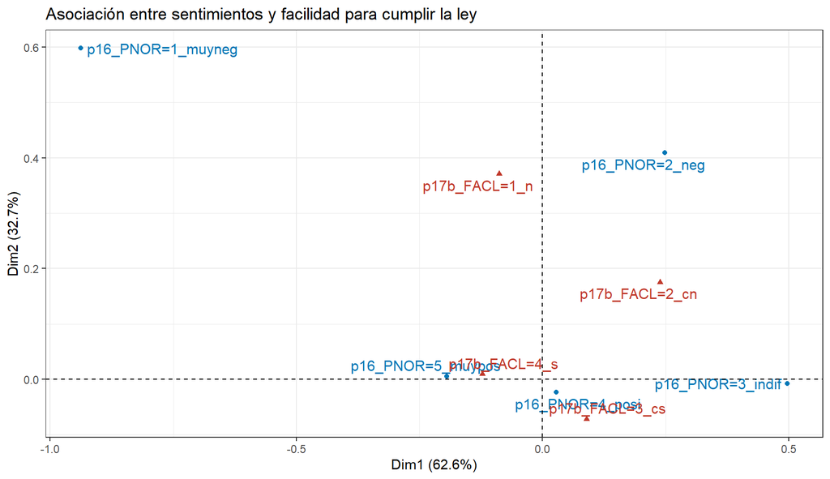

**Note**

## Variable suplementaria: nivel educativo

¿Tienen los niveles educativos más altos mayor facilidad para cumplir la ley o mejores sentimientos hacia las normas?

```r
Nedx17  <- table(CCLatin$p7_NEd, CCLatin$p17_b)
pnor_Ned_faci <- rbind(as.data.frame.matrix(t16x17), as.data.frame.matrix(Nedx17))
ca_supl <- CA(pnor_Ned_faci, row.sup = 6:11, graph = FALSE)
```

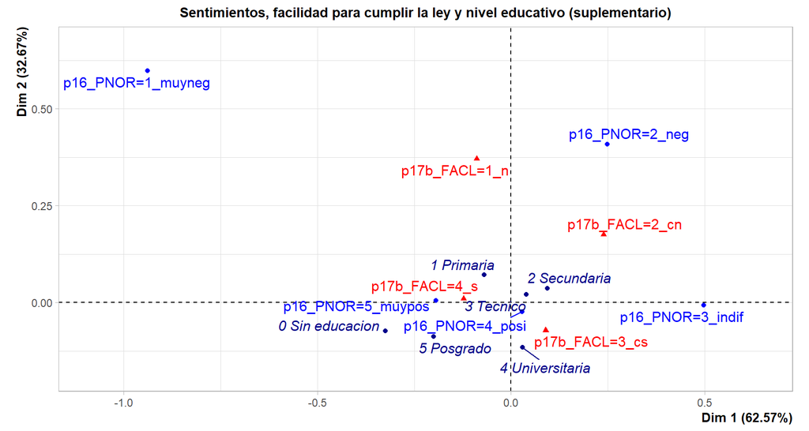

```r
plot.CA(ca_supl, title = "Sentimientos, facilidad para cumplir la ley y nivel educativo (suplementario)")
```

## Variable suplementaria: indicadores por nivel educativo

| Nivel educativo | Coordenadas F1 | Coordenadas F2 | Cos² F1 | Cos² F2 |
| --- | --- | --- | --- | --- |
| 0 Sin educacion | -0.32 | -0.07 | 0.72 | 0.04 |
| 1 Primaria | -0.07 | 0.07 | 0.41 | 0.42 |
| 2 Secundaria | 0.09 | 0.04 | 0.74 | 0.11 |
| 3 Tecnico | 0.04 | 0.02 | 0.34 | 0.10 |
| 4 Universitaria | 0.03 | -0.12 | 0.06 | 0.94 |
| 5 Posgrado | -0.20 | -0.09 | 0.55 | 0.11 |

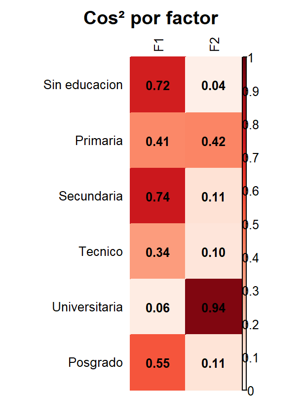

**Note**

# Ejemplo 2: Confianza en la justicia en 38 países

## Encuesta Mundial de Valores

La **Encuesta Mundial de Valores** se realiza periódicamente desde 1981 e indaga opiniones sobre democracia, tolerancia, religión, medio ambiente y diversidad, entre otros temas.

Una de sus preguntas interroga por el **grado de confianza en la justicia** en 38 países, incluyendo varios latinoamericanos. La variable-fila es el **país** y la variable-columna es el **nivel de confianza** declarado por los encuestados.

```r
library(pacman)
p_load(tidyverse, janitor, FactoMineR, factoextra, corrplot)

conf_just <- read.csv2(paste0(url, "ConfianzaJUsticia.csv")) |>
             column_to_rownames("Pais") |>
             arrange(desc(muchis.))
```

## Tabla de contingencia: Países × Niveles de confianza

Grados de confianza en la justicia (Encuesta Mundial de Valores)

| País | muchis. | mucho | no_mucho | nada | no_sabe | no_resp. |
| --- | --- | --- | --- | --- | --- | --- |
| Dinamarca | 861 | 2 | 536 | 85 | 41 | 5 |
| Alemania | 549 | 2 | 952 | 195 | 119 | 15 |
| Canada | 375 | 2 | 1 | 324 | 0 | 0 |
| Austria | 332 | 860 | 361 | 77 | 17 | 4 |
| Rumania | 323 | 833 | 928 | 598 | 168 | 23 |
| Suiza | 317 | 2 | 787 | 126 | 44 | 19 |
| R Unido | 317 | 819 | 521 | 104 | 31 | 1 |
| Noruega | 299 | 666 | 131 | 15 | 13 | 0 |
| E Unidos | 289 | 1 | 909 | 173 | 3 | 27 |
| Australia | 254 | 814 | 569 | 155 | 0 | 21 |
| Finlandia | 241 | 721 | 201 | 34 | 19 | 3 |
| Suecia | 219 | 692 | 218 | 39 | 29 | 1 |
| Nueva Zelanda | 213 | 504 | 247 | 39 | 20 | 0 |
| Brasil | 208 | 678 | 404 | 408 | 60 | 4 |
| Paises Bajos | 205 | 1 | 802 | 151 | 135 | 5 |
| Francia | 189 | 907 | 525 | 211 | 47 | 1 |
| Hungria | 156 | 578 | 509 | 234 | 31 | 11 |
| Islandia | 155 | 826 | 535 | 86 | 26 | 5 |
| Espana | 155 | 414 | 447 | 180 | 8 | 5 |
| Estonia | 142 | 606 | 358 | 71 | 112 | 15 |
| Grecia | 130 | 580 | 353 | 119 | 11 | 7 |
| Italia | 125 | 785 | 944 | 372 | 42 | 14 |
| Serbia | 123 | 613 | 1 | 622 | 95 | 30 |
| Chequia | 117 | 563 | 736 | 303 | 86 | 24 |
| Mexico | 105 | 280 | 552 | 778 | 23 | 1 |
| Chipre | 101 | 391 | 347 | 113 | 40 | 7 |
| Colombia | 96 | 105 | 885 | 434 | 0 | 0 |
| Ecuador | 90 | 394 | 460 | 237 | 19 | 0 |
| Lituania | 79 | 616 | 537 | 101 | 112 | 8 |
| Portugal | 78 | 515 | 386 | 187 | 32 | 3 |
| Eslovaquia | 72 | 415 | 615 | 302 | 12 | 20 |
| Polonia | 62 | 413 | 532 | 249 | 94 | 8 |
| Eslovenia | 50 | 187 | 547 | 268 | 22 | 6 |
| Chile | 43 | 258 | 443 | 235 | 19 | 2 |
| Bulgaria | 40 | 187 | 717 | 550 | 54 | 18 |
| Croacia | 36 | 168 | 618 | 623 | 36 | 12 |
| Peru | 25 | 110 | 389 | 861 | 10 | 6 |
| Argentina | 17 | 176 | 427 | 365 | 16 | 1 |

## ACS: Confianza en la justicia

```r
acs_conf <- CA(conf_just, graph = FALSE)
#round(get_eigenvalue(acs_conf), 3)
```

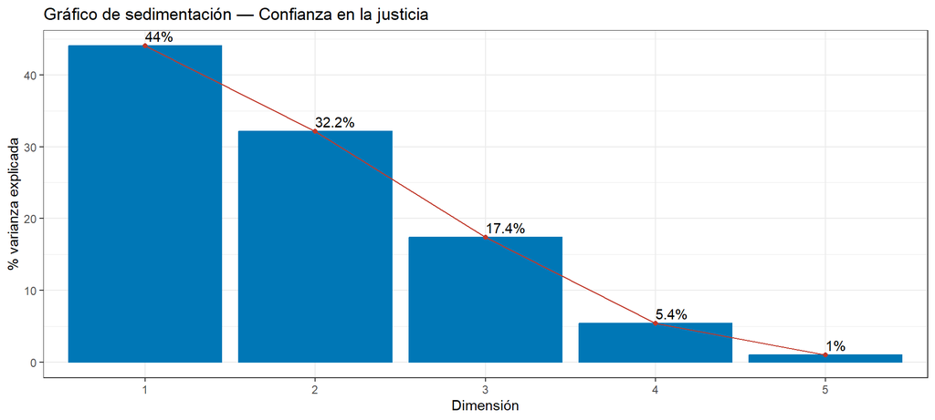

```r
fviz_eig(acs_conf, addlabels = TRUE, barfill = "#0077b6", barcolor = "#0077b6", linecolor = "#C0392B") +
  labs(title = "Gráfico de sedimentación — Confianza en la justicia", x = "Dimensión", y = "% varianza explicada") + theme_bw()
```

## Plano de columnas: niveles de confianza

```r
fviz_ca_col(acs_conf, repel = TRUE,
            col.col = "contrib",
            gradient.cols = c("#00AFBB", "#E7B800", "#FC4E07"),
            title = "Niveles de confianza — por contribución") + theme_bw()
```

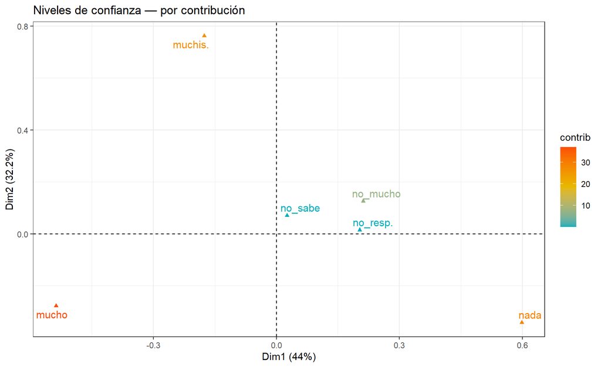

## Plano de filas: países

```r
fviz_ca_row(acs_conf, repel = TRUE, labelsize = 3,
            col.row = "cos2",
            gradient.cols = c("#00AFBB", "#E7B800", "#FC4E07"),
            title = "Países — grado de confianza en la justicia (cos²)") + theme_bw()
```

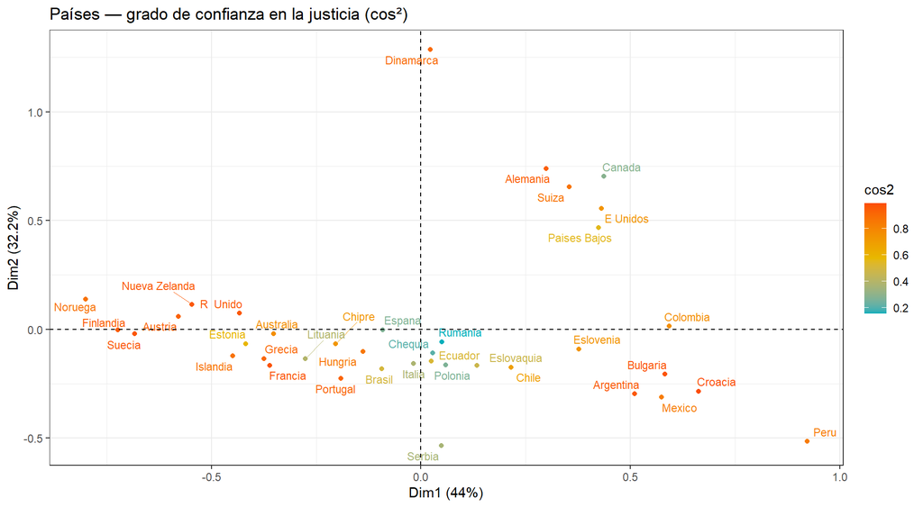

## Representación simultánea: países y niveles de confianza

```r
fviz_ca_biplot(acs_conf, repel = TRUE, labelsize = 3,
               col.row = "#0077b6", col.col = "#C0392B",
               title = "Asociación entre países y niveles de confianza en la justicia") +
  theme_bw()
```

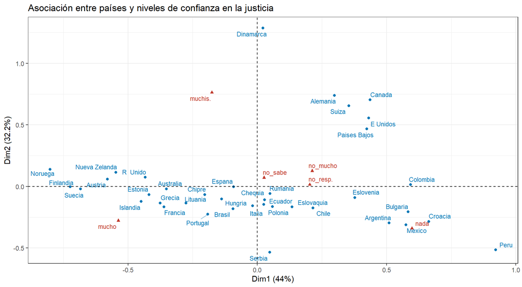

## Interpretación

# Ejemplo 3: Elecciones Alcaldía de Bogotá 2023

## Contexto

En contextos electorales, identificar la percepción ciudadana hacia los candidatos resulta fundamental. Los datos analizados provienen de una muestra aleatoria de 300 personas, extraída de un estudio con 4894 encuestas aplicadas en todas las localidades de Bogotá. El instrumento evaluó a los candidatos a la Alcaldía de Bogotá 2023 mediante preguntas de selección múltiple, donde los participantes asignaron diversos atributos a cada perfil.

La tabla resultante es:

| Dimensión | Descripción |
| --- | --- |
| **Filas** | 26 atributos percibidos (positivos, negativos, ideológicos, de alineación política) |
| **Columnas** | 9 candidatos (incluye “Ninguno” y “Ns/Nr”) |

El ACS permite construir el **mapa perceptivo** de los candidatos.

## Diseño del cuestionario

Se entrega a los entrevistados una tarjeta con la imagen y nombres de los candidatos. Luego se leen los atributos y para cada uno el encuestado responde con cuál(es) candidatos lo asocia.

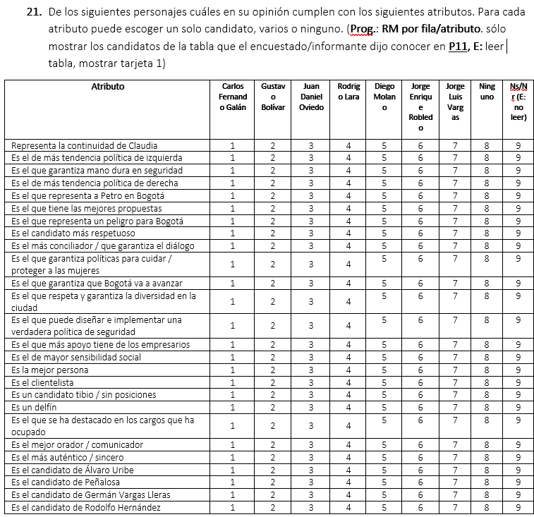

## Carga de los datos

```r
library(pacman)
p_load(here, tidyverse, FactoMineR, factoextra, corrplot,
       ggrepel, gt, janitor, haven)

url <- "https://github.com/jgbabativam/Curso_Multivariado/raw/main/Datos/"
clase <- read_sav(paste0(url, "df_clase.sav"))
```

Explore el conjunto de datos con `glimpse(as_factor(clase))` y compare con el cuestionario

## Ordenar y transformar

[Fuente: tidyexplain](https://www.garrickadenbuie.com/project/tidyexplain/)

## Preparación de los datos

```r
df_long <- clase |>
  pivot_longer(cols = starts_with("P21"), names_to = "P21", values_to = "respuesta") |>
  filter(!is.na(respuesta))

max_dig <- max(nchar(as.character(as.numeric(df_long$respuesta))), na.rm = TRUE)
cols_resp <- paste0("r_", 0:max_dig)

df1 <- df_long |>
  mutate(respuesta = as.character(as.numeric(respuesta))) |>
  filter(!is.na(respuesta)) |>
  separate(respuesta, into = cols_resp, sep = "", fill = "right") |>
  select(-r_0)

df_reest <- df1 |>
  pivot_longer(cols = starts_with("r_"),
               names_to = "var", values_to = "candidato",
               values_drop_na = TRUE) |>
  filter(candidato != "" & candidato != "0") |>
  select(-var) |>
  separate(P21, c("pregunta", "item"), sep = "_") |>
  mutate(
    item = factor(as.integer(item), levels = 1:26,
      labels = c("Continuidad Claudia","Izquierda","Mano dura",
                 "Derecha","Representa Petro","Mejores propuestas",
                 "Peligro p/Bogotá","Más respetuoso","Más conciliador",
                 "Protege mujeres","Bogotá avanza","Respeta diversidad",
                 "Política seguridad","Apoyo empresarial","Sensibilidad social",
                 "Mejor persona","Clientelista","Tibio","Delfín",
                 "Destacado en cargos","Mejor comunicador","Más auténtico",
                 "Cand. Uribe","Cand. Peñalosa","Cand. Vargas Ll.","Cand. Rodolfo")),
    candidato = factor(as.integer(candidato), levels = 1:9,
      labels = c("C.F. Galán","G. Bolívar","J.D. Oviedo","R. Lara",
                 "D. Molano","J.E. Robledo","J.L. Vargas","Ninguno","Ns/Nr"))
  ) |>
  select(-pregunta)
```

## Tabla de contingencia: atributos × candidatos

```r
tabla_cand <- df_reest |>
  count(item, candidato) |>
  pivot_wider(names_from = candidato, values_from = n, values_fill = 0) |>
  column_to_rownames("item")
```

| Atributo | C.F. Galán | G. Bolívar | J.D. Oviedo | R. Lara | D. Molano | J.E. Robledo | J.L. Vargas | Ninguno | Ns/Nr |
| --- | --- | --- | --- | --- | --- | --- | --- | --- | --- |
| Continuidad Claudia | 116 | 26 | 53 | 14 | 10 | 23 | 5 | 82 | 17 |
| Izquierda | 27 | 160 | 12 | 8 | 5 | 15 | 3 | 58 | 25 |
| Mano dura | 88 | 23 | 22 | 29 | 48 | 12 | 30 | 65 | 19 |
| Derecha | 97 | 15 | 35 | 35 | 54 | 11 | 18 | 63 | 24 |
| Representa Petro | 16 | 173 | 10 | 4 | 4 | 6 | 3 | 72 | 22 |
| Mejores propuestas | 123 | 47 | 45 | 19 | 14 | 13 | 8 | 60 | 21 |
| Peligro p/Bogotá | 16 | 100 | 26 | 18 | 35 | 15 | 13 | 107 | 25 |
| Más respetuoso | 114 | 43 | 73 | 26 | 20 | 22 | 15 | 40 | 20 |
| Más conciliador | 117 | 45 | 66 | 23 | 15 | 23 | 7 | 43 | 17 |
| Protege mujeres | 111 | 40 | 52 | 19 | 15 | 21 | 8 | 63 | 30 |
| Bogotá avanza | 140 | 48 | 39 | 16 | 16 | 19 | 8 | 65 | 13 |
| Respeta diversidad | 108 | 55 | 71 | 16 | 13 | 17 | 8 | 56 | 19 |
| Política seguridad | 100 | 34 | 31 | 20 | 32 | 16 | 28 | 73 | 16 |
| Apoyo empresarial | 132 | 17 | 23 | 21 | 29 | 13 | 12 | 58 | 36 |
| Sensibilidad social | 87 | 65 | 52 | 23 | 13 | 23 | 7 | 62 | 22 |
| Mejor persona | 105 | 38 | 46 | 17 | 13 | 13 | 7 | 76 | 20 |
| Clientelista | 53 | 57 | 19 | 29 | 31 | 25 | 6 | 92 | 47 |
| Tibio | 42 | 35 | 37 | 37 | 20 | 29 | 10 | 106 | 28 |
| Delfín | 78 | 22 | 14 | 38 | 17 | 12 | 3 | 99 | 58 |
| Destacado en cargos | 96 | 42 | 64 | 19 | 18 | 33 | 12 | 55 | 21 |
| Mejor comunicador | 116 | 49 | 34 | 22 | 18 | 29 | 6 | 55 | 22 |
| Más auténtico | 89 | 48 | 45 | 16 | 16 | 25 | 5 | 74 | 18 |
| Cand. Uribe | 34 | 7 | 15 | 18 | 56 | 10 | 14 | 117 | 63 |
| Cand. Peñalosa | 44 | 6 | 21 | 18 | 14 | 13 | 7 | 114 | 82 |
| Cand. Vargas Ll. | 38 | 3 | 8 | 29 | 16 | 12 | 15 | 117 | 79 |
| Cand. Rodolfo | 20 | 3 | 9 | 10 | 10 | 7 | 5 | 154 | 92 |

## ACS — Perfil de candidatos

```r
res <- CA(tabla_cand, graph = FALSE)
fviz_screeplot(res, addlabels = TRUE, ylim = c(0, 50), barfill = "#0077b6", barcolor = "#0077b6", linecolor = "#C0392B") +
  labs(title = "Gráfico de sedimentación — Candidatos Bogotá 2023",
       x = "Dimensión", y = "% varianza explicada") + theme_bw()
```

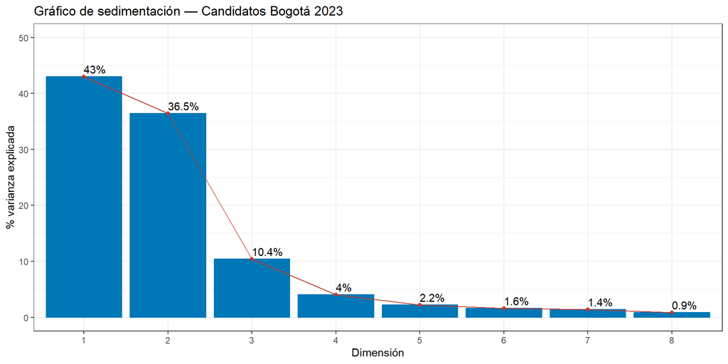

## Contribuciones de las columnas (candidatos)

```r
corrplot(res$col$contrib, is.corr=FALSE, tl.col = "black")
```

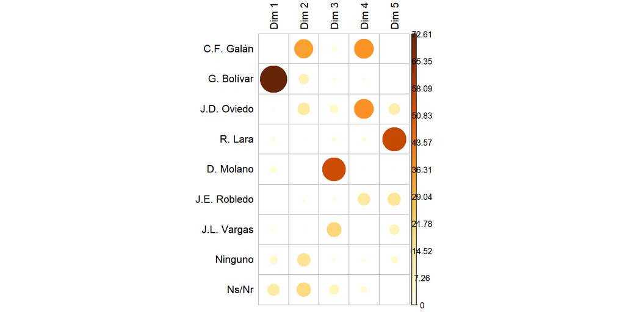

## Contribuciones de las filas (atributos)

```r
corrplot(res$row$contrib, is.corr=FALSE, tl.col = "black")
```

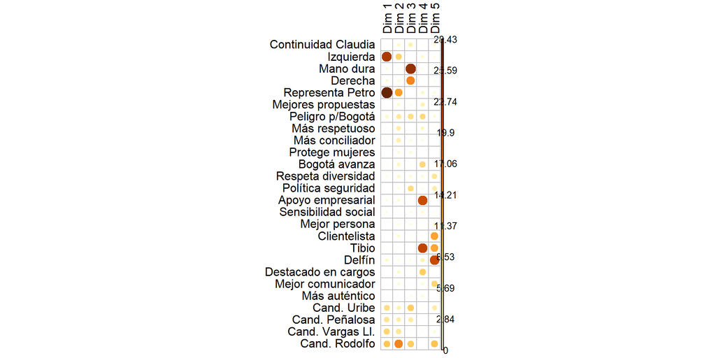

## Análisis de los cosenos para los candidatos

```r
corrplot(res$col$cos2, is.corr=FALSE, tl.col = "black")
```

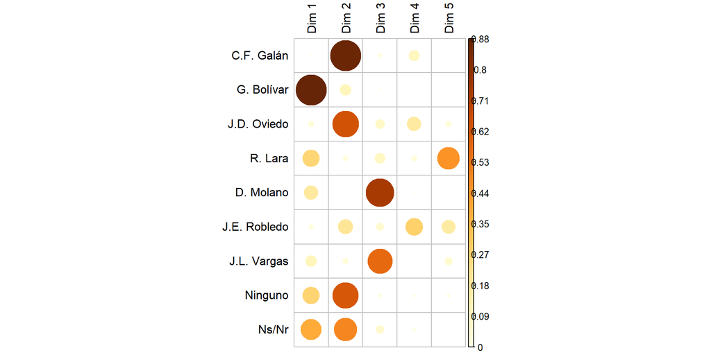

## Análisis de los cosenos para los atributos

```r
corrplot(res$row$cos2, is.corr=FALSE, tl.col = "black")
```

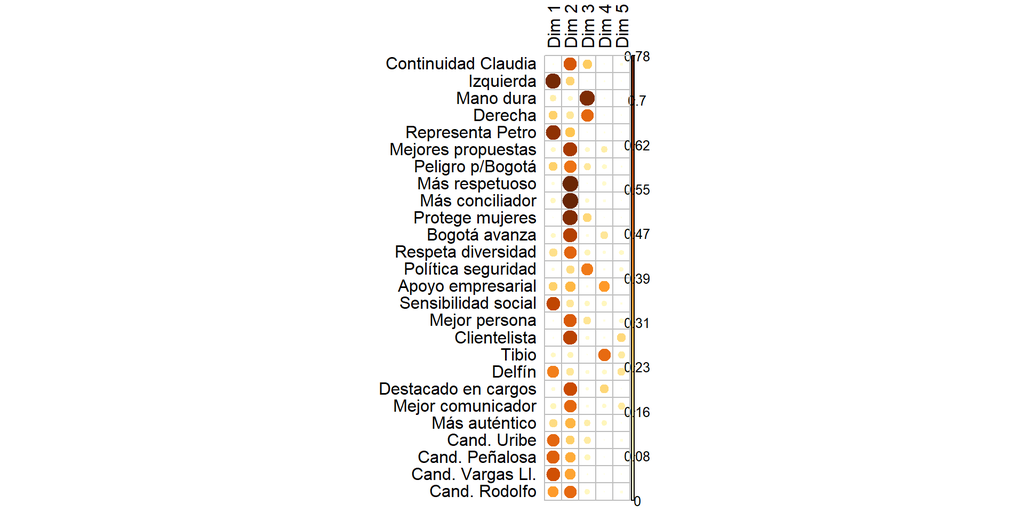

## Perfil de los candidatos (Plano 1-2)

```r
fviz_ca_col(res, repel = TRUE, col.col = "cos2", axes = c(1,2),
            gradient.cols = c("#00AFBB", "#E7B800", "#FC4E07"),
            select.col = list(cos2 = 0.5))
```

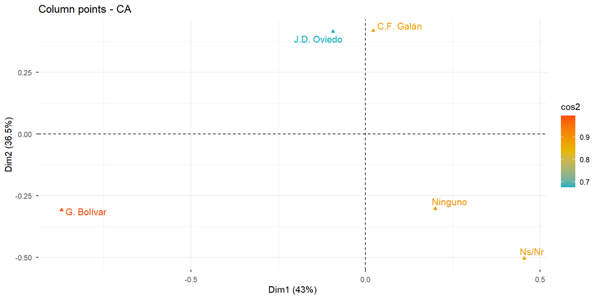

## Posicionamiento de los atributos (Plano 1-2)

```r
fviz_ca_row(res, repel = TRUE, col.row = "cos2", axes = c(1,2),
            gradient.cols = c("lightblue", "blue", "darkblue"),
            select.row = list(cos2 = 0.5))
```

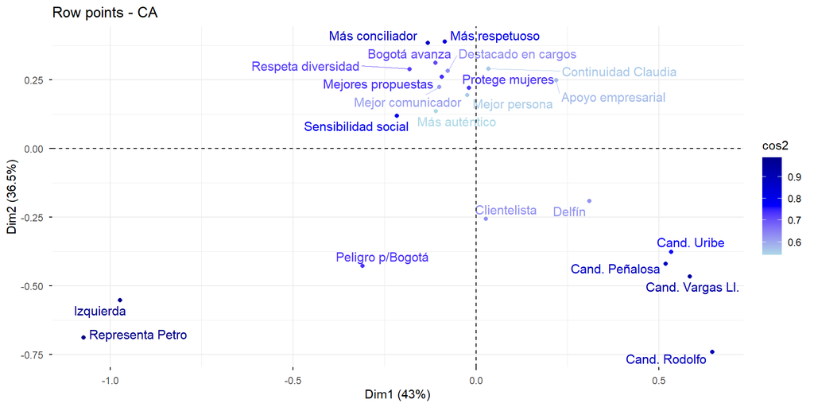

## Biplot: candidatos y atributos

```r
fviz_ca_biplot(res, axes = c(1,2),
               repel = TRUE,
               select.col = list(cos2 = 0.5),
               select.row = list(cos2 = 0.5))
```

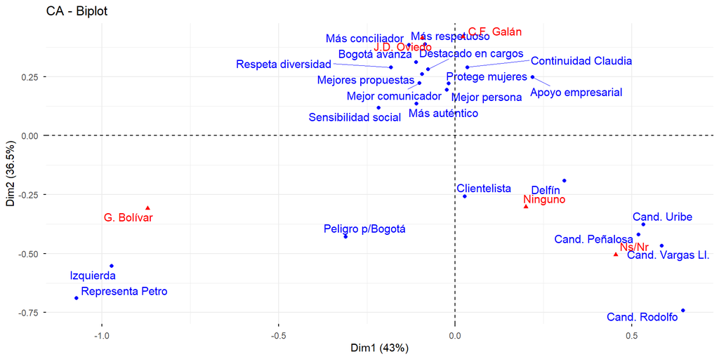

## Análisis complementarios

1. Haga un análisis que le permita encontrar las diferencias y similaridades entre los candidatos Galán, Oviedo, Molano y Vargas.
2. ¿Cuáles son los aspectos que diferencian al candidato Lara frente a los candidatos Galán y Oviedo?.
3. ¿Que modificación debe realizar si su objetivo se centra en encontrar los aspectos que diferencian al candidato Lara frente a los candidatos Molano y Vargas?.

# Análisis de Correspondencias Múltiples (ACM)

## Del ACS al ACM

El ACS identifica asociaciones entre **dos** variables cualitativas. Cuando el interés se centra en $Q \geq 3$ preguntas cualitativas, se generaliza al **Análisis de Correspondencias Múltiples (ACM)**.

El ACM se construye sobre una **Tabla de Tablas de Contingencia** denominada **tabla de Burt**, que es una matriz simétrica por bloques donde cada bloque es la tabla de frecuencias entre un par de variables:

## Matriz disyuntiva

Suponiendo $n$ individuos que responden $Q$ preguntas, la respuesta a la pregunta $q$ (con $p_q$ modalidades) se codifica en una **matriz disyuntiva** $Z_q$ de dimensiones $n \times p_q$:

$$Z_q \in \mathbb{R}^{n \times p_q}$$

cuyos elementos son:

$$Z_q = \{ z_q(i,k) \}, \quad
i = 1, \dots, n,\;
k = 1, \dots, p_q,\;
q = 1, \dots, Q$$

donde

$$z_q(i,k) =
\begin{cases}
1 & \text{si el individuo } i \text{ seleccionó la opción } k \text{ de la pregunta } q \\
0 & \text{en caso contrario}
\end{cases}$$

## Matriz disyuntiva completa

La **matriz disyuntiva completa** concatena todas las preguntas:

$$Z = [Z_1,\, Z_2,\, \cdots,\, Z_Q] \qquad (n \times p), \quad p = \sum_{q=1}^Q p_q$$

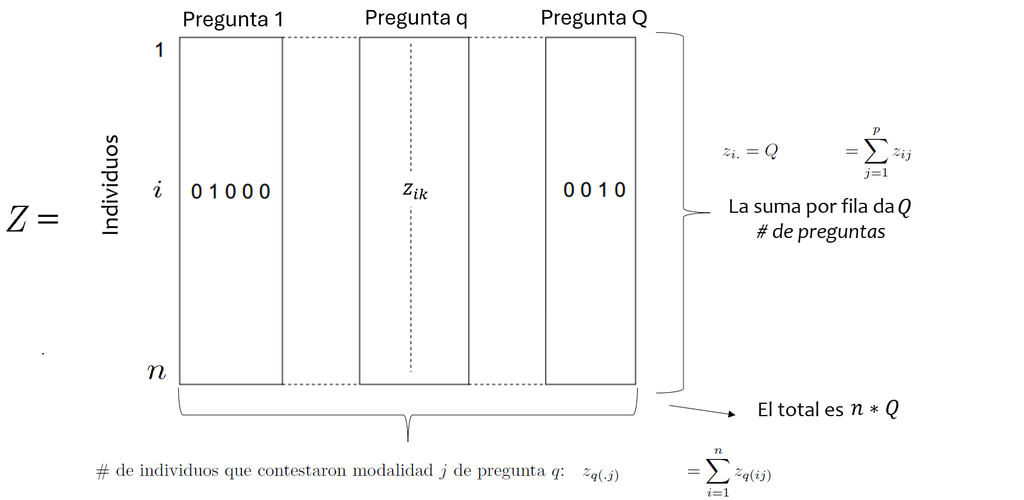

## Ejemplo: Matriz disyuntiva completa

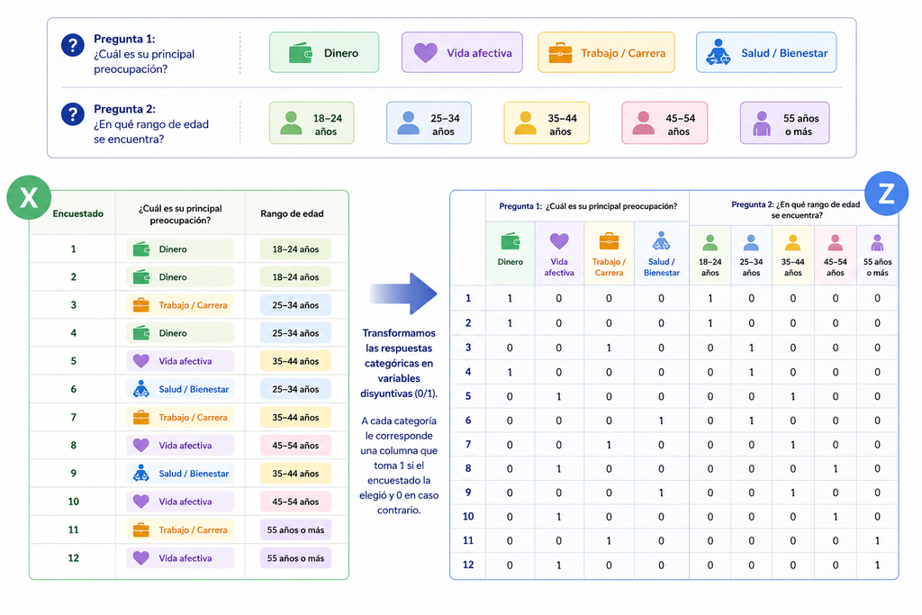

# Tabla de Burt

Al realizar la operación $Z^\prime Z$ se llega a la matriz que concatena todas las tablas de contingencia entre pares de variables, denominada tabla de *Burt*

$$B = Z^\prime Z = \begin{bmatrix} Z_1^\prime Z_1 & Z_1^\prime Z_2 & \cdots & Z_1^\prime Z_Q \\ Z_2^\prime Z_1 & Z_2^\prime Z_2 & \cdots & Z_2^\prime Z_Q \\ \vdots & \vdots & \ddots & \vdots \\ Z_Q^\prime Z_1 & Z_Q^\prime Z_2 & \cdots & Z_Q^\prime Z_Q \end{bmatrix}$$

> La equivalencia entre un ACM para dos preguntas y un ACS está documentada en Lebart et al. (1984).

## Tabla de Burt: estructura por bloques

La tabla de Burt $B = Z^\prime Z$ es simétrica por bloques:

**En la diagonal** — tablas de contingencia internas de la pregunta $q$:
$$D_q = Z_q^\prime Z_q = \text{diag}(z_{q(\cdot 1)},\, z_{q(\cdot 2)},\, \ldots,\, z_{q(\cdot p_q)}), \quad q=1, \ldots, Q$$

**Fuera de la diagonal** — tablas de contingencia entre las preguntas $q$ y $q^\prime$:
$$Z_q^\prime Z_{q^\prime} = \left\{ \sum_{i=1}^n z_{q(ij)}\, z_{q^\prime(ik)} \right\}_{j,k}$$
cuyo elemento $(j,k)$ es el número de individuos que contestaron la opción $j$ de $q$ **y** la opción $k$ de $q^\prime$.

## Tabla de Burt: estructura por bloques

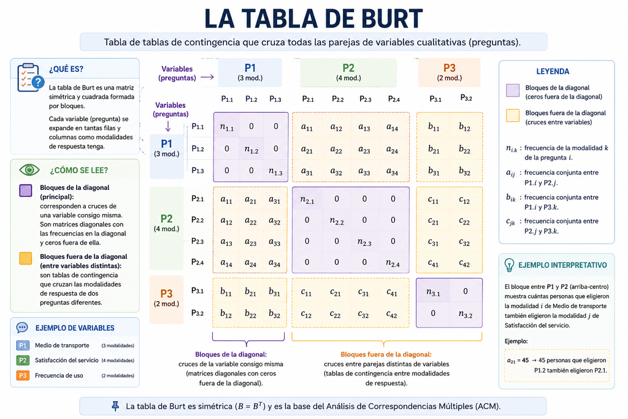

## Ejemplo: Tabla de Burt

[figure not shown]

## Obtención de las componentes

Para el ACM se usan entonces los perfiles fila y columna de la tabla disyuntiva completa, se mantiene el criterio de distancia $\chi^2$ y las interpretaciones son los mismos que los del ACS.

La matriz a la que se calculan los valores y vectores propios es:

$$S = \frac{1}{Q} Z^\prime Z D^{-1} = \frac{1}{Q} B D^{-1}$$

donde

- $D^{-1} = \text{diag}(D_1^{-1}, D_2^{-1}, \ldots, D_Q^{-1})$
- $D_q^{-1} = Z_q^\prime Z_q = \text{diag}(1/z_{q(\cdot 1)}, 1/z_{q(\cdot 2)}, \ldots, 1/z_{q(\cdot p_q)}), \quad q=1,\ldots Q$

# Inercia en el ACM

## Inercia de modalidades, preguntas y total

**Inercia (varianza) de una modalidad** $j$:

$$I(j) = \frac{1}{Q}\left(1 - \frac{z_{.j}}{n}\right)$$

Aumenta cuando **pocos individuos** la contestaron ($z_{.j}$ pequeño); disminuye con $Q$.

**Inercia de una pregunta completa** $q$:

$$I(q) = \sum_{j=1}^{p_q} I(j) = \sum_{j=1}^{p_q} \frac{1}{Q}\left(1 - \frac{z_{.j}}{n}\right) = \frac{1}{Q}(p_q - 1)$$

Solo depende de $p_q$ y $Q$: **no tiene interés estadístico**.

**Inercia total:**

$$IT = \sum_q I(q) = \frac{p}{Q} - 1$$

También es función de $p$ y $Q$, por lo que **tampoco tiene interés estadístico**.

## Conclusión sobre la inercia

**Important**

**La única inercia con interés real para la interpretación es la de las modalidades**, porque depende de la proporción de respuestas que tuvo cada modalidad en la encuesta:

$$I(j) = \frac{1}{Q}\left(1 - \frac{z_{.j}}{n}\right)$$

Las modalidades **raramente contestadas** tienen inercia alta: son las que más distinguen a los individuos y aparecerán lejos del origen en el plano factorial.

> Esta propiedad del ACM es especialmente útil en investigación social: las respuestas atípicas o poco comunes revelan los grupos más diferenciados de la población encuestada.

# Interpretación del ACM

## Guías para la interpretación

Todas las reglas del ACS son aplicables directamente al ACM. Adicionalmente:

- **Proximidad entre individuos** → respondieron aproximadamente las mismas opciones de respuesta; tienen opiniones similares.
- **Proximidad entre modalidades de preguntas diferentes** → asociación entre ellas: fueron contestadas aproximadamente por los mismos individuos.
- **Proximidad entre modalidades de la misma pregunta** → las distribuciones de quienes las contestaron son similares (aunque sean excluyentes).
- **Modalidades suplementarias (cualitativas):** no participan en el cálculo pero se proyectan en el plano. Sus posiciones indican tendencias o perfiles.
- **Variables suplementarias cuantitativas:** se correlacionan con los factores usando la correlación variable–factor ($\sqrt{\lambda_\alpha}\, v_{j\alpha}$), igual que en ACP.

# Ejemplo 1: Justificaciones para desobedecer la ley — ECC

## Descripción del ejemplo

La ECC incluye una pregunta que indaga si se justifica o no desobedecer la ley en 11 circunstancias (ítems). Para cada ítem el encuestado responde **sí** o **no**.

Las justificaciones son:

| a. Alcanzar sus objetivos | g. No hay castigo |
| --- | --- |
| b. Ayudar a la familia | h. Alguien lo ha hecho y le fue bien |
| c. Luchar contra ley o régimen injusto | i. Es lo acostumbrado |
| d. Por provecho económico | j. Pagar un favor |
| e. Creencia religiosa lo permite | k. Defender propiedades o bienes |
| f. Responder a una ofensa al honor |  |

Se incluyen ciudad y nivel educativo como **variables suplementarias**.

## Carga y preparación de los datos

```r
cclp20 <- CCLatin[, c(4, 8, 64:74)]

etiq_si <- c("Si alcanzar objetivos","Si ayudar familia",
             "Si lucha ley reg injusto","Si por provecho económico",
             "Si creencia religiosa","Si resp. ofensa honor",
             "Si no hay castigo","Si alg ha hecho y ha ido bien",
             "Si es lo acostumbrado","Si pagar favor",
             "Si defender prop o bienes")

nombres_p20 <- paste0("P20_", letters[1:11])
for (k in seq_along(nombres_p20)) {
  col <- nombres_p20[k]
  cclp20[[col]][grepl("=1_si", cclp20[[col]])] <- etiq_si[k]
}

# Variables activas: ítems p20a-p20k (sin ciudad ni nivel educativo)
datos_acm <- cclp20[, -(1:2)]
```

## ACM — Valores propios

```r
acm_p20 <- MCA(datos_acm, graph = FALSE)
```

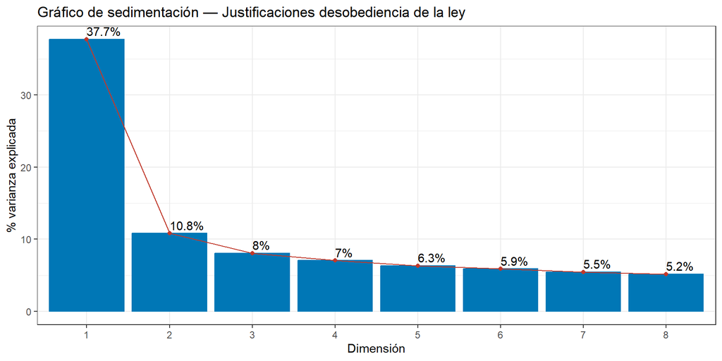

```r
fviz_eig(acm_p20, addlabels = TRUE, ncp = 8,
         barfill = "#0077b6", barcolor = "#0077b6", linecolor = "#C0392B") +
  labs(title = "Gráfico de sedimentación — Justificaciones desobediencia de la ley",
       x = "Dimensión", y = "% varianza explicada") + theme_bw()
```

## Indicadores de modalidades

```r
indp20 <- round(cbind(acm_p20$var$coord[, 1:3],
                      acm_p20$var$contrib[, 1:3],
                      acm_p20$var$cos2[, 1:3]), 2)
indp20 <- indp20[order(indp20[, 4], decreasing = TRUE), ]
colnames(indp20) <- c("Coo F1","Coo F2","Coo F3",
                      "Con F1","Con F2","Con F3",
                      "Cos F1","Cos F2","Cos F3")
head(indp20, 12)
```

```
                              Coo F1 Coo F2 Coo F3 Con F1 Con F2 Con F3 Cos F1
Si no hay castigo               1.58   0.39   0.18   9.49   2.01   0.56   0.47
Si por provecho económico       1.60   0.19   0.64   9.29   0.47   7.01   0.45
Si es lo acostumbrado           1.82   1.09  -0.33   9.29  11.62   1.45   0.44
Si alg ha hecho y ha ido bien   1.86   1.17   0.34   8.37  11.64   1.32   0.39
Si pagar favor                  1.71   1.10  -0.97   8.02  11.58  12.08   0.37
Si creencia religiosa           1.57   0.20   1.21   7.36   0.43  20.43   0.35
Si resp. ofensa honor           1.09  -0.30  -0.08   6.96   1.88   0.16   0.38
Si alcanzar objetivos           1.11  -0.59   0.32   6.86   6.81   2.64   0.37
Si defender prop o bienes       0.73  -0.21  -0.82   4.76   1.39  27.69   0.31
Si lucha ley reg injusto        0.72  -0.63   0.15   4.67  12.52   0.93   0.31
Si ayudar familia               0.62  -0.60  -0.16   4.14  13.29   1.25   0.31
p20b_RDL_AF=2_no               -0.50   0.48   0.13   3.30  10.60   1.00   0.31
                              Cos F2 Cos F3
Si no hay castigo               0.03   0.01
Si por provecho económico       0.01   0.07
Si es lo acostumbrado           0.16   0.01
Si alg ha hecho y ha ido bien   0.15   0.01
Si pagar favor                  0.16   0.12
Si creencia religiosa           0.01   0.21
Si resp. ofensa honor           0.03   0.00
Si alcanzar objetivos           0.11   0.03
Si defender prop o bienes       0.03   0.39
Si lucha ley reg injusto        0.24   0.01
Si ayudar familia               0.28   0.02
p20b_RDL_AF=2_no                0.28   0.02
```

## Plano 1-2: modalidades de respuesta

```r
fviz_mca_var(acm_p20, repel = TRUE, labelsize = 3,
             col.var = "contrib",
             gradient.cols = c("#00AFBB", "#E7B800", "#FC4E07"),
             title = "Plano 1-2: Justificaciones para desobedecer la ley") + theme_bw()
```

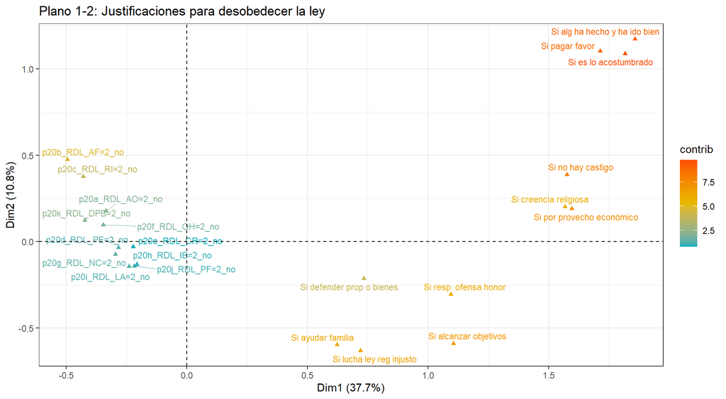

## Interpretación del Factor 1 y Factor 2

- Sobre el **Factor 1**: todas las respuestas “Sí” tienen coordenadas **positivas**; las respuestas “No” tienen coordenadas **negativas**. Es un indicador de la **disposición general a justificar la desobediencia** de la ley.
- Las mayores contribuciones al Factor 1 son de “Sí no hay castigo” y “Sí por provecho económico”: justificaciones de carácter **oportunista/impunidad**.
- El **Factor 2** está tipificado por “Sí ayudar familia” y “Sí lucha contra ley injusta”: justificaciones de tipo **prosocial o cívico**, cualitativamente distintas.
- El Factor 3 distingue “Sí defender propiedades” y “Sí creencia religiosa”: justificaciones más **individuales o filosóficas**.

## Plano 1-2 con variables suplementarias

```r
# Construir tabla con ciudad (col 4) y nivel educativo (col 8) como suplementarias
# y P20_a...P20_k (cols 64-74) como variables activas
cclp20_ilus <- CCLatin[, c(4, 8, 64:74)]

for (k in seq_along(nombres_p20)) {
  col <- nombres_p20[k]
  cclp20_ilus[[col]][grepl("=1_si", as.character(cclp20_ilus[[col]]))] <- etiq_si[k]
}

acm_supl <- MCA(cclp20_ilus, quali.sup = c(1, 2), graph = FALSE)
```

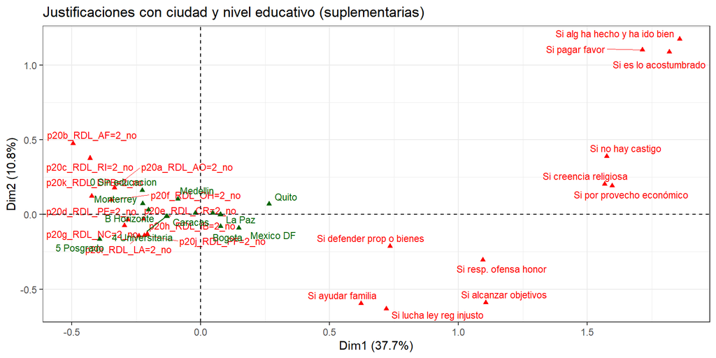

```r
fviz_mca_var(acm_supl, repel = TRUE, labelsize = 3,
             title = "Justificaciones con ciudad y nivel educativo (suplementarias)") +
  theme_bw()
```

# Ejemplo 2: Confianza en instituciones — LAPOP Colombia 2021

## Contexto: Barómetro de las Américas

El **Barómetro de las Américas** (LAPOP) es la encuesta de opinión pública más grande de América Latina. La edición Colombia 2021 tiene 2 993 encuestados. Usa un diseño de **muestra dividida**: distintos módulos de preguntas van a diferentes subconjuntos.

El ejemplo usa seis preguntas del **mismo módulo** (n ≈ 1 368, escala 1–7):

| Variable | Dimensión |
| --- | --- |
| `b2` | Respeto por las instituciones políticas |
| `b3` | Derechos básicos bien protegidos |
| `b4` | Orgullo por el sistema político |
| `b6` | Apoyo al sistema político |
| `b32` | Confianza en el gobierno local |
| `b47a` | Confianza en las elecciones |

Las escalas 1–7 se recodifican: **Baja** (1–3) · **Media** (4) · **Alta** (5–7). El género (`q1tb`: Hombre/Mujer) se incluye como **variable suplementaria**.

## Carga y recodificación

```r
lapop_raw <- read_dta(paste0(url, "COL_2021_LAPOP.dta"))

recode_trust <- function(x) {
  xn <- suppressWarnings(as.numeric(x))
  dplyr::case_when(
    xn %in% 1:3 ~ "Baja",
    xn == 4     ~ "Media",
    xn %in% 5:7 ~ "Alta",
    TRUE        ~ NA_character_
  )
}

lapop_acm <- lapop_raw |>
  transmute(
    Respeto    = recode_trust(b2),
    Derechos   = recode_trust(b3),
    Orgullo    = recode_trust(b4),
    Apoyo      = recode_trust(b6),
    GobLocal   = recode_trust(b32),
    Elecciones = recode_trust(b47a),
    Genero = dplyr::case_when(
      as.numeric(q1tb) == 1 ~ "Hombre",
      as.numeric(q1tb) == 2 ~ "Mujer",
      TRUE ~ NA_character_
    )
  ) |>
  drop_na() |>
  mutate(across(everything(), factor))
```

## ACM — Valores propios

```r
acm_lapop <- MCA(lapop_acm,
                 quali.sup = which(names(lapop_acm) == "Genero"),
                 graph = FALSE)
```

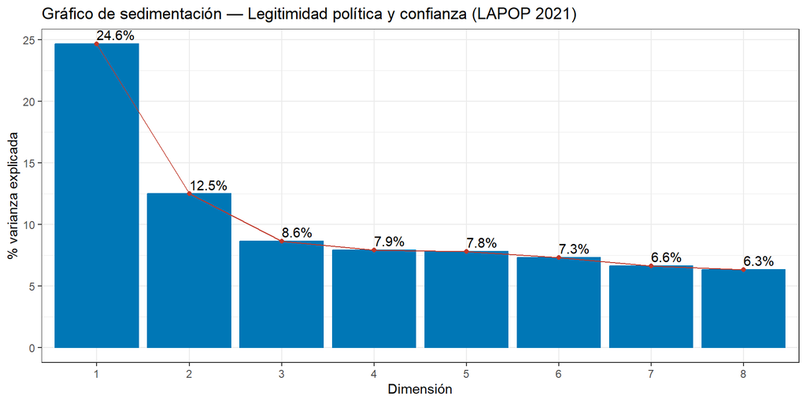

```r
fviz_eig(acm_lapop, addlabels = TRUE, ncp = 8,
         barfill = "#0077b6", barcolor = "#0077b6", linecolor = "#C0392B") +
  labs(title = "Gráfico de sedimentación — Legitimidad política y confianza (LAPOP 2021)",
       x = "Dimensión", y = "% varianza explicada") + theme_bw()
```

## Plano 1-2: modalidades de confianza

```r
fviz_mca_var(acm_lapop, repel = TRUE, labelsize = 3.5,
             col.var = "contrib",
             gradient.cols = c("#00AFBB", "#E7B800", "#FC4E07"),
             title = "Legitimidad política y confianza institucional — LAPOP Colombia 2021") + theme_bw()
```

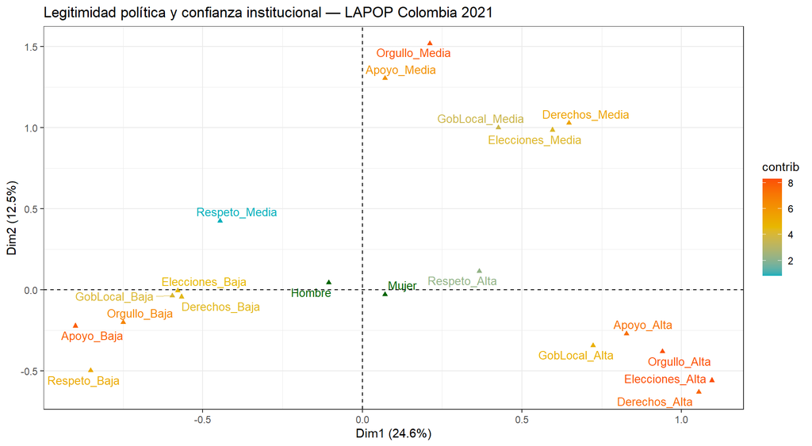

## Plano con género como variable suplementaria

```r
fviz_mca_var(acm_lapop, repel = TRUE, labelsize = 3.5,
             col.var.sup = "#C0392B",
             title = "Legitimidad política con género del encuestado (suplementario) — LAPOP 2021") +
  theme_bw()
```

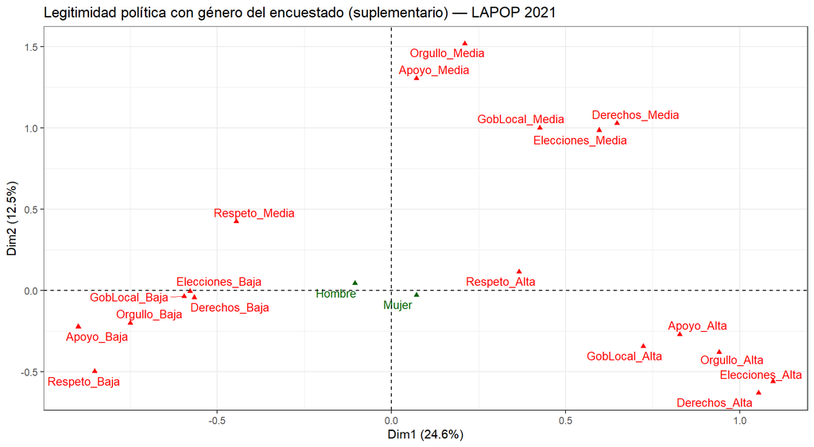

## Plano de individuos

```r
fviz_mca_ind(acm_lapop, geom = "point", alpha.ind = 0.3,
             col.ind = "cos2",
             gradient.cols = c("#00AFBB", "#E7B800", "#FC4E07"),
             title = "Encuestados — Legitimidad política LAPOP Colombia 2021") + theme_bw()
```

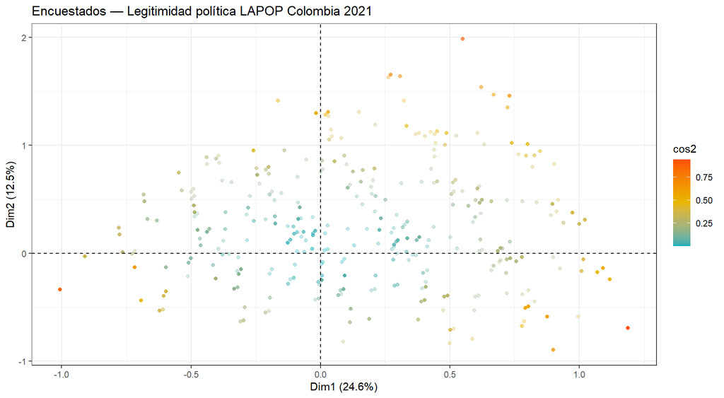

# Laboratorio

## Datos del laboratorio

Los ejercicios utilizan los datos de la **Encuesta de Cultura Ciudadana (ECC)** disponible en el repositorio del curso.

```r
library(pacman)
p_load(tidyverse, FactoMineR, factoextra, haven, corrplot)

url   <- "https://github.com/jgbabativam/Curso_Multivariado/raw/main/Datos/"
datos <- read.csv2(paste0(url, "Muestra_CC.csv"), sep = ";")
```

Las variables de interés son:

| Variable | Descripción |
| --- | --- |
| `p16` | Sentimientos ante palabras “regla o norma” (1=muy negativo a 5=muy positivo) |
| `p17_b` | Facilidad para actuar conforme a la ley (1=nunca a 4=siempre) |
| `p21` | Preferencia para celebrar acuerdos |
| `p7_NEd` | Nivel educativo |
| `citi` | Ciudad |
| `p20a`–`p20k` | Justificaciones para desobedecer la ley (si/no) |

## Asignación por grupos

Cada grupo trabajará con semilla distinta y una **pareja de preguntas diferente para el ACS** y un **conjunto distinto de ítems para el ACM**.

| Grupo | Semilla | ACS: variables | ACM: ítems p20 |
| --- | --- | --- | --- |
| 1 | 1357 | `p16` × `p17_b` | a, b, c, d, e (objetivos, familia, régimen, económico, religión) |
| 2 | 2468 | `p17_b` × `p21` | f, g, h, i, j (honor, impunidad, costumbre, favor) |
| 3 | 3579 | `p16` × `p21` | c, d, e, f, k (régimen, económico, religión, honor, propiedad) |
| 4 | 9753 | `p21` × `p7_NEd` | a, g, h, i, j, k (objetivos, impunidad, costumbre, favor, propiedad) |

## Laboratorio — ACS (1/3)

Con la pareja de variables asignada a su grupo:

1. Construya la **tabla de contingencia** e interprete las frecuencias marginales: ¿qué modalidades son más frecuentes?
2. Calcule y grafique los **perfiles fila** y los **perfiles columna**. ¿Observa algún patrón? ¿Qué modalidades tienen distribuciones más similares entre sí?
3. Aplique el ACS con `CA()` del paquete `FactoMineR`.
4. ¿Cuántos factores retiene? Justifique con el **porcentaje de varianza acumulada** y el gráfico de sedimentación.
5. Construya el **análisis por filas** (coordenadas, contribuciones, cos²). Identifique las dos modalidades que mejor tipifican el Factor 1 y las que mejor tipifican el Factor 2.

## Laboratorio — ACS (2/3)

6. Construya el **análisis por columnas**. Identifique la modalidad con mayor contribución al Factor 1 y la con mayor cos² en el Factor 2.
7. Construya la **representación simultánea** (biplot) de filas y columnas. Describa al menos **tres asociaciones** entre modalidades de las dos variables que pueda identificar en el plano.
8. Agregue la variable **`citi` (ciudad)** como variable suplementaria (`row.sup`). ¿Alguna ciudad muestra una tendencia particular en las variables analizadas?
9. Agregue el **nivel educativo `p7_NEd`** como variable suplementaria. ¿Los niveles educativos más altos tienden a agregar con alguna modalidad particular?

## Laboratorio — ACM (3/3)

Con los ítems de justificación para desobedecer la ley asignados a su grupo:

1. Aplique el **ACM** con `MCA()`. ¿Cuántos factores capturan el 50% de la varianza? Justifique la elección.
2. Construya la tabla de **coordenadas, contribuciones y cos²** para las primeras 3 dimensiones. ¿Qué modalidades definen el Factor 1?
3. Construya el **plano 1-2 de modalidades** (`fviz_mca_var`). Identifique los grupos de justificaciones con perfiles similares.
4. Agregue **ciudad y nivel educativo** como variables suplementarias (`quali.sup`). ¿Alguna ciudad muestra mayor tendencia a justificar la desobediencia? ¿Hay diferencias por nivel educativo?
5. Elabore un **análisis interpretativo** de los factores identificados, nombrando cada dimensión según las modalidades que la tipifican.